# Amandafw_OriginalHomeworkCode_04

Amanda Wu

2023-10-23

## Question 1

```r
# p1 = probabilities of success / estimated proportions of sample 1
# n1 = count of trails / sample size of sample 1
# x = sample of the data set
library(BSDA)
set.seed(1)
p1 <- 24
p2 <- 35
n1 <- 50
n2 <- 80
dataset <- rnorm(n1, mean = p1, sd = 5) # making the data set
dataset2 <- rnorm(n2, mean = p2, sd = 7) # second data set

z.prop.test <- function (p1, p2 = NULL, n1, n2 = NULL, alternative = "two.sided", p0, conf.level = 0.95)  # function was written from the information in the instructions and entering z.test on console
{
    choices <- c("two.sided", "greater", "less")
    alt <- pmatch(alternative, choices)
    alternative <- choices[alt] # don't really understand why this is here but it was shown when you enter z.test on console

    if (!is.null(n1)) {
        if (n1 * p1 <= 5 || n1 * (1 - p1) <= 5) { # one sample test
          print("Warning! Normal Distribution should not be assumed")
           }
        } else {
           if (n2 * p2 <= 5 || n2 * (1 - p2) <= 5) { # two sample test
    print("Warning! Normal Distribution should not be assumed")
           }
        }

    p1ok <- !is.na(p1) # checking the length of x without na
    p1 <- p1[p1ok] #code was included in the z.test function
    np1 <- length(p1)
    mp1 <- mean(p1) #calculating mean of p1
    estimate <- mp1
    if (is.null(n1)) {
        stderr <- sigma.x/sqrt(np1) # this is calculating sem
        zobs <- (mp1 - n0)/stderr # this is calculating z
        method <- c("One-sample z-Test") # output
        names(estimate) <- c("mean of p1") # output
    }
    else {
        p2ok <- !is.na(p2) # same as above
        p2 <- p2[p2ok]
        np2 <- length(p2)
        mp2 <- mean(p2)
        method <- c("Two-sample z-Test")
        estimate <- c(mp1, mp2)
        names(estimate) <- c("mean of p1", "mean of p2")
        stderr <- sqrt(((sigma.x^2)/np1) + ((sigma.y^2)/np2))
        zobs <- (mp1 - mp2 - n0)/stderr
    }
    if (alternative == "less") {
        pval <- pnorm(zobs)
        cint <- c(NA, zobs * stderr + qnorm(conf.level) * stderr)
    }
    else if (alternative == "greater") {
        pval <- 1 - pnorm(zobs)
        cint <- c(zobs * stderr - qnorm(conf.level) * stderr,
            NA)
    }
    else {
        pval <- 2 * pnorm(-abs(zobs))
        alpha <- 1 - conf.level
        cint <- c(zobs * stderr - qnorm((1 - alpha/2)) * stderr,
            zobs * stderr + qnorm((1 - alpha/2)) * stderr)
    }
    cint <- cint + mu
    names(zobs) <- "z"
    if (!is.null(p2))
        names(n0) <- "difference in means"
    else names(n0) <- "mean"
    attr(cint, "conf.level") <- conf.level
    rval <- list(statistic = zobs, p.value = pval, conf.int = cint,
        estimate = estimate, null.value = mu, alternative = alternative,
        method = method, data.name = dname)
    attr(rval, "class") <- "htest"
    return(rval)
}
```

## Question 2

```r
library(curl)
```

```r
library(ggplot2)
library(tidyverse)
f <- curl("https://raw.githubusercontent.com/fuzzyatelin/fuzzyatelin.github.io/master/AN588_Fall23/KamilarAndCooperData.csv") #pulling the data into R
d <- read.csv(f, header = TRUE, sep = ",", stringsAsFactors = FALSE)
head(d)
```

```
##               Scientific_Name          Family          Genus      Species
## 1 Allenopithecus_nigroviridis Cercopithecidae Allenopithecus nigroviridis
## 2         Allocebus_trichotis Cercopithecidae      Allocebus    trichotis
## 3           Alouatta_belzebul        Atelidae       Alouatta     belzebul
## 4             Alouatta_caraya        Atelidae       Alouatta       caraya
## 5            Alouatta_guariba        Atelidae       Alouatta      guariba
## 6           Alouatta_palliata        Atelidae       Alouatta     palliata
##   Brain_Size_Species_Mean Brain_Size_Female_Mean   Brain_size_Ref
## 1                   58.02                  53.70 Isler et al 2008
## 2                      NA                     NA
## 3                   52.84                  51.19 Isler et al 2008
## 4                   52.63                  47.80 Isler et al 2008
## 5                   51.70                  49.08 Isler et al 2008
## 6                   49.88                  48.04 Isler et al 2008
##   Body_mass_male_mean Body_mass_female_mean Mass_Dimorphism
```

[output cut: 62 more lines]

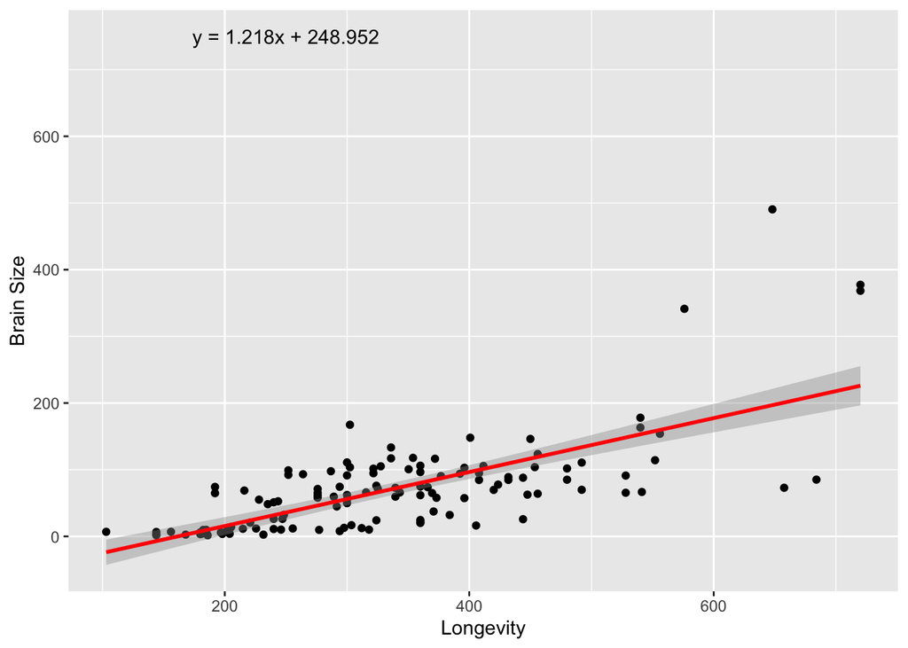

```r
# Fit the regression model and, using {ggplot2}, produce a scatterplot with the fitted line superimposed upon the data. Append the the fitted model equation to your plot (HINT: use the function geom_text()).
p <- ggplot(d = d, aes(x = MaxLongevity_m, y = Brain_Size_Species_Mean))
p <- p + xlab("Longevity") + ylab("Brain Size")  #renaming the axis
p <- p + geom_point()  #make a scatterplot
p <- p + geom_smooth(method = "lm", level = .95, color = "red") #adding regression lines
p <- p + annotate("text", x = 250, y = 750, label = "y = 1.218x + 248.952") #using annotate after Lily told me about the function since geom_text didn't work
p
```

```r
lm(d$MaxLongevity_m ~ d$Brain_Size_Species_Mean) # gave me the fitted model equation
```

```
##
## Call:
## lm(formula = d$MaxLongevity_m ~ d$Brain_Size_Species_Mean)
##
## Coefficients:
##               (Intercept)  d$Brain_Size_Species_Mean
##                   248.952                      1.218
```

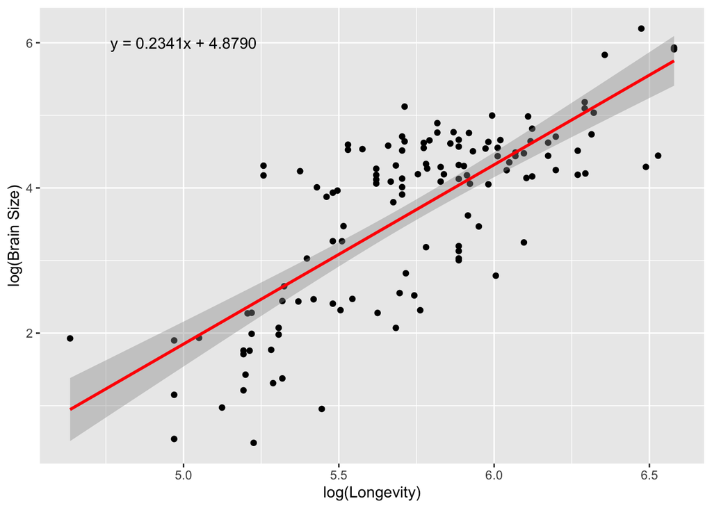

```r
# log(longevity) & log(brain size) scatterplot
Longevity <- log(d$MaxLongevity_m)
Brainsize <- log(d$Brain_Size_Species_Mean)
p <- ggplot(d = d, aes(x = Longevity, y = Brainsize))
p <- p + xlab("log(Longevity)") + ylab("log(Brain Size)")  #renaming the axis
p <- p + geom_point()  #make a scatterplot
p <- p + geom_smooth(method = "lm", level = .95, color = "red") #adding regression lines
p <- p + annotate("text", x = 5, y = 6, label = "y = 0.2341x + 4.8790")
p
```

```r
lm(data = d, log(MaxLongevity_m) ~ log(Brain_Size_Species_Mean)) # gave me the fitted model equation
```

```
##
## Call:
## lm(formula = log(MaxLongevity_m) ~ log(Brain_Size_Species_Mean),
##     data = d)
##
## Coefficients:
##                  (Intercept)  log(Brain_Size_Species_Mean)
##                       4.8790                        0.2341
```

```r
# Identify and interpret the point estimate of the slope (β1), as well as the outcome of the test associated with the hypotheses H0: β1 = 0; HA: β1 ≠ 0. Also, find a 90 percent CI for the slope (β1) parameter.
Model <- lm(data = d, MaxLongevity_m ~ Brain_Size_Species_Mean)
PE <- predict(Model, newdata = data.frame(Brain_Size_Species_Mean = 1.218), interval = "prediction", level = 0.90)
head(PE,1) #this doesn't seem like the correct value
```

```
##        fit      lwr     upr
## 1 250.4358 98.69057 402.181
```

```r
confint(Model, level = 0.90) #finding CI
```

```
##                                5 %      95 %
## (Intercept)             230.540738 267.36379
## Brain_Size_Species_Mean   1.035571   1.40041
```

```r
# for log version

Model <- lm(data = d, log(MaxLongevity_m) ~ log(Brain_Size_Species_Mean))
PE <- predict(Model, newdata = data.frame(Brain_Size_Species_Mean = 0.2341), interval = "prediction", level = 0.90)
head(PE,1) # this value looks alot better than one above
```

```
##        fit      lwr      upr
## 1 4.538964 4.098812 4.979116
```

```r
confint(Model, level = 0.90)
```

```
##                                    5 %      95 %
## (Intercept)                  4.7644934 4.9934084
## log(Brain_Size_Species_Mean) 0.2046396 0.2636595
```

The point estimate of the slope (β1) is the expected change in units of y for every 1 unit of change in x while β0 is the predicted value of y when the value of x is zero. Source: https://rstudio-pubs-static.s3.amazonaws.com/364807_2a19c487ae5e433eb22f61b641b9b12c.html#section_32:_the_least_squares_point_estimates

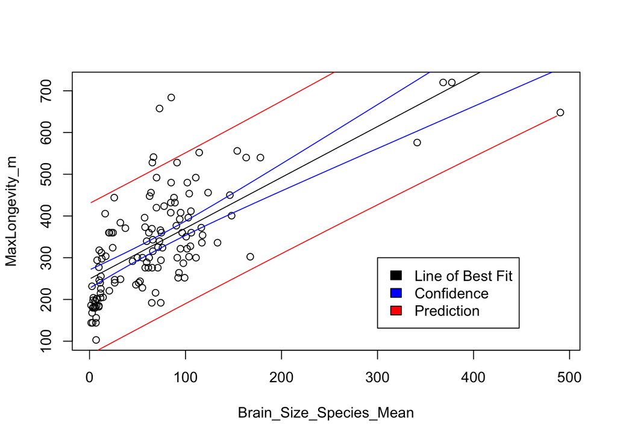

```r
# Using your model, add lines for the 90 percent confidence and prediction interval bands on the plot and add a legend to differentiate between the lines.
v <-  seq(from = 1.63, to = 491.27, by = 5) #taken from using summary(m) ?
m <- lm(data = d, MaxLongevity_m ~ Brain_Size_Species_Mean)
ci <- predict(m, newdata = data.frame(Brain_Size_Species_Mean = v), interval = "confidence", level = 0.95) #straight from mod 12
pi <- predict(m, newdata = data.frame(Brain_Size_Species_Mean = v), interval = "prediction", level = 0.95)
plot(data = d, MaxLongevity_m ~ Brain_Size_Species_Mean)
lines(x = v, y = ci[, 1], col = "black") #straight from mod 12
lines(x = v, y = ci[, 2], col = "blue")
lines(x = v, y = ci[, 3], col = "blue")
lines(x = v, y = pi[, 2], col = "red")
lines(x = v, y = pi[, 3], col = "red")
legend(300, 300, legend=c("Line of Best Fit", "Confidence", "Prediction"), fill = c("black", "blue","red"))
```

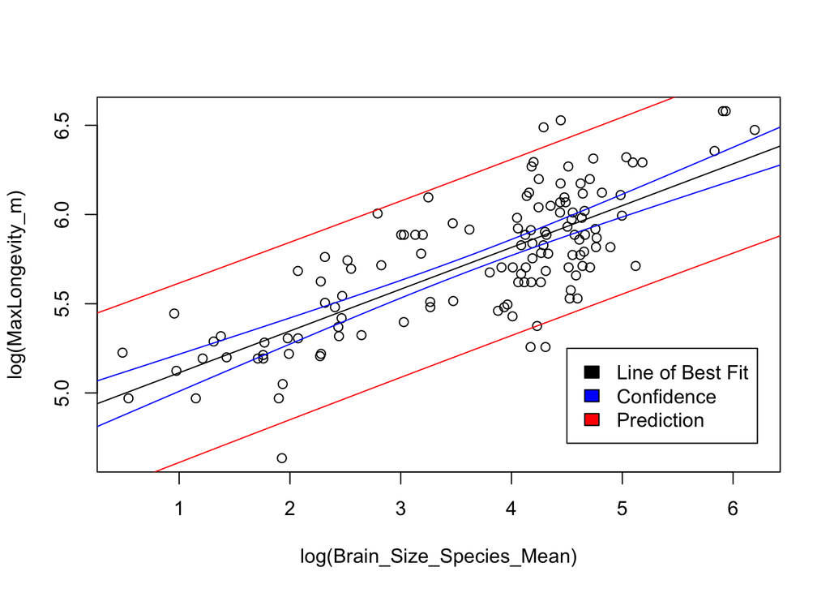

```r
# log version
v <-  seq(from = 0, to = 7, by = .05)
Longevity <- log(d$MaxLongevity_m)
Brainsize <- log (d$Brain_Size_Species_Mean)
m <- lm(Longevity ~ Brainsize)
ci <- predict(m, newdata = data.frame(Brainsize = v), interval = "confidence", level = 0.95)
pi <- predict(m, newdata = data.frame(Brainsize = v), interval = "prediction", level = 0.95)
plot(data = d, log(MaxLongevity_m) ~ log(Brain_Size_Species_Mean))
lines(x = v, y = ci[, 1], col = "black")
lines(x = v, y = ci[, 2], col = "blue")
lines(x = v, y = ci[, 3], col = "blue")
lines(x = v, y = pi[, 2], col = "red")
lines(x = v, y = pi[, 3], col = "red")
legend(4.5, 5.25, legend=c("Line of Best Fit", "Confidence", "Prediction"), fill = c("black", "blue","red"))
```

Source: https://www.geeksforgeeks.org/add-legend-to-plot-in-r/ (for the legend); code was taken almost completely from module 12 Notes: this is a pretty ugly graph .. it took me so long to do because I kept running into the error “Error in xy.coords(x, y) : ‘x’ and ‘y’ lengths differ” when I tried to do Longevity as X and Brain Size as Y The logged version looks way better !

```r
# Produce a point estimate and associated 90 percent PI for the longevity of a species whose brain weight is 800 gm. Do you trust the model to predict observations accurately for this value of the explanatory variable? Why or why not?

Model <- lm(d$MaxLongevity_m ~ d$Brain_Size_Species_Mean)
species <- predict(Model, newdata = data.frame(MaxLongevity_m = 800), interval = "prediction", level = 0.90)
head(species,1)
```

```
##        fit     lwr      upr
## 1 319.6201 168.375 470.8651
```

```r
Model <- lm(data = d, Longevity ~ Brainsize)
logspecies <- predict(Model, newdata = data.frame(Brainsize = 800, interval = "prediction", level = 0.90))
head(logspecies, 1) # this value looks alot better than one above
```

```
##        1
## 192.1986
```

I’m not sure if it’s my function, but the CI is extremely wide which wouldn’t be reliable. The log version appears to be better

### Conclusion: Looking at the two models, the log version definitely looks better as their values are smaller and appear more concise. I had some difficulties calculating the log values though as it wouldn’t always work with the same functions as normal.